# CUSTOMER CHURN MANAGEMENT

# INTRODUCTION

## Churn definition

Customer churn is a major problem for most of the companies. Losing customers require gaining new customers to replace them. This could be around 10X more expensive than retaining existing customers, depending on the domain.

A customer is considered as churn when he/she stop using your company’s product or service. This is easy to define it for contractual setting, as a customer is considered as churn when fails to renew the contract. But in a non-contractual setting there aren’t clear rules for defining churn. In most of these cases, business users with extended domain knowledge together with data scientists/data analysts define what is considered as churn in the specific problem. e.g. in a retail organization the team could define that a customer is a churn when fails to purchase for the last 4 months.

## Benefits of churn management

The main benefit is increased revenue by obtaining higher retention rates and customer satisfaction. The other benefit is the optimization of marketing expenditures with targeted marketing campaigns & reallocation of marketing budgets.

## Churn rate

You can calculate churn rate by dividing the number of customers lost during a specific time period – say a quarter or a year – by the number of customers we had at the beginning of that time period.

For example, if we start the quarter with 400 customers and end with 380, our churn rate is 5% because we lost 5% or 20 of our customers.

## Our churn problem

Our case study is a telecommunication company that wants to develop a churn model to predict the probability of a new customer to churn. The telecommunications sector has become one of the main industries in developed countries. The technical progress and the increasing number of operators raised the level of competition. Companies are working hard to survive in this competitive market depending on multiple strategies.

Three main strategies have been proposed to generate more revenues:

- Acquire new customers
- Upsell the existing customers (persuade a customer to buy something additional or more expensive)
- Increase the retention period of customers.

In our case, we focus on the last strategy i.e. increase the retention period of customers.

## Import libraries

At first we are loading all libraries.

```r
library(tidyverse)
library(ggthemes)
library(correlationfunnel)
library(knitr)
library(caret)
library(recipes)
library(yardstick)
# Set the black & white theme for all plots
theme_set(theme_bw())
```

## Load dataset

We use the read_csv() function (from readr library) to read the csv file in R.

```r
telco <- read_csv(file = "data/WA_Fn-UseC_-Telco-Customer-Churn.csv")
```

# EXPLORATORY ANALYSIS

## Inspect the dataset

Use glimpse() function to inspect the dataset on console or View() to inspect the data in a spreadsheet-type format.

```r
telco %>% glimpse()
```

```
Rows: 7,043
Columns: 21
$ customerID       <chr> "7590-VHVEG", "5575-GNVDE", "3668-QPYBK", "7795-CFOCW", "9237-HQITU", "9305-CDSKC"…
$ gender           <chr> "Female", "Male", "Male", "Male", "Female", "Female", "Male", "Female", "Female", …
$ SeniorCitizen    <dbl> 0, 0, 0, 0, 0, 0, 0, 0, 0, 0, 0, 0, 0, 0, 0, 0, 0, 0, 0, 0, 1, 0, 0, 0, 0, 0, 0, 0…
$ Partner          <chr> "Yes", "No", "No", "No", "No", "No", "No", "No", "Yes", "No", "Yes", "No", "Yes", …
$ Dependents       <chr> "No", "No", "No", "No", "No", "No", "Yes", "No", "No", "Yes", "Yes", "No", "No", "…
$ tenure           <dbl> 1, 34, 2, 45, 2, 8, 22, 10, 28, 62, 13, 16, 58, 49, 25, 69, 52, 71, 10, 21, 1, 12,…
$ PhoneService     <chr> "No", "Yes", "Yes", "No", "Yes", "Yes", "Yes", "No", "Yes", "Yes", "Yes", "Yes", "…
$ MultipleLines    <chr> "No phone service", "No", "No", "No phone service", "No", "Yes", "Yes", "No phone …
$ InternetService  <chr> "DSL", "DSL", "DSL", "DSL", "Fiber optic", "Fiber optic", "Fiber optic", "DSL", "F…
$ OnlineSecurity   <chr> "No", "Yes", "Yes", "Yes", "No", "No", "No", "Yes", "No", "Yes", "Yes", "No intern…
$ OnlineBackup     <chr> "Yes", "No", "Yes", "No", "No", "No", "Yes", "No", "No", "Yes", "No", "No internet…
$ DeviceProtection <chr> "No", "Yes", "No", "Yes", "No", "Yes", "No", "No", "Yes", "No", "No", "No internet…
$ TechSupport      <chr> "No", "No", "No", "Yes", "No", "No", "No", "No", "Yes", "No", "No", "No internet s…
$ StreamingTV      <chr> "No", "No", "No", "No", "No", "Yes", "Yes", "No", "Yes", "No", "No", "No internet …
$ StreamingMovies  <chr> "No", "No", "No", "No", "No", "Yes", "No", "No", "Yes", "No", "No", "No internet s…
$ Contract         <chr> "Month-to-month", "One year", "Month-to-month", "One year", "Month-to-month", "Mon…
$ PaperlessBilling <chr> "Yes", "No", "Yes", "No", "Yes", "Yes", "Yes", "No", "Yes", "No", "Yes", "No", "No…
$ PaymentMethod    <chr> "Electronic check", "Mailed check", "Mailed check", "Bank transfer (automatic)", "…
$ MonthlyCharges   <dbl> 29.85, 56.95, 53.85, 42.30, 70.70, 99.65, 89.10, 29.75, 104.80, 56.15, 49.95, 18.9…
$ TotalCharges     <dbl> 29.85, 1889.50, 108.15, 1840.75, 151.65, 820.50, 1949.40, 301.90, 3046.05, 3487.95…
$ Churn            <chr> "No", "No", "Yes", "No", "Yes", "Yes", "No", "No", "Yes", "No", "No", "No", "No", …
```

- Customer ID
- gender | Whether the customer is a male or a female
- SeniorCitizen | Whether the customer is a senior citizen or not (1, 0)
- Partner | Whether the customer has a partner or not (Yes, No)
- Dependents | Whether the customer has dependents or not (Yes, No)
- tenure | Number of months the customer has stayed with the company
- PhoneService | Whether the customer has a phone service or not (Yes, No)
- MultipleLines | Whether the customer has multiple lines or not (Yes, No, No phone service)
- InternetService | Customer’s internet service provider (DSL, Fiber optic, No)
- OnlineSecurity | Whether the customer has online security or not (Yes, No, No internet service)
- OnlineBackup | Whether the customer has online backup or not (Yes, No, No internet service)
- DeviceProtection | Whether the customer has device protection or not (Yes, No, No internet service)
- TechSupport | Whether the customer has tech support or not (Yes, No, No internet service)
- StreamingTV | Whether the customer has streaming TV or not (Yes, No, No internet service)
- StreamingMovies | Whether the customer has streaming movies or not (Yes, No, No internet service)
- Contract | The contract term of the customer (Month-to-month, One year, Two years)
- PaperlessBilling | Whether the customer has paperless billing or not (Yes, No)
- PaymentMethod | The customer’s payment method (Electronic check, Mailed check, Bank transfer (automatic), Credit card (automatic))
- MonthlyCharges | The amount charged to the customer monthly
- TotalCharges | The total amount charged to the customer
- Churn | Whether the customer churned or not (Yes or No)

## Check for missing values

One of the most common problems in any data analysis is to discover & handle missing data.

| customerID | gender | SeniorCitizen | Partner | Dependents | tenure | PhoneService | MultipleLines | InternetService | OnlineSecurity | OnlineBackup | DeviceProtection | TechSupport | StreamingTV | StreamingMovies | Contract | PaperlessBilling | PaymentMethod | MonthlyCharges | TotalCharges | Churn |
| --- | --- | --- | --- | --- | --- | --- | --- | --- | --- | --- | --- | --- | --- | --- | --- | --- | --- | --- | --- | --- |
| 7590-VHVEG | Female | 0 | Yes | No | 1 | No | No phone service | DSL | No | Yes | No | No | No | No | Month-to-month | Yes | Electronic check | 29.85 | 29.85 | No |
| 5575-GNVDE | Male | 0 | No | No | 34 | Yes | No | DSL | Yes | No | Yes | No | No | No | One year | No | Mailed check | 56.95 | 1889.50 | No |
| 3668-QPYBK | Male | 0 | No | No | 2 | Yes | No | DSL | Yes | Yes | No | No | No | No | Month-to-month | Yes | Mailed check | 53.85 | 108.15 | Yes |
| 7795-CFOCW | Male | 0 | No | No | 45 | No | No phone service | DSL | Yes | No | Yes | Yes | No | No | One year | No | Bank transfer (automatic) | 42.30 | 1840.75 | No |
| 9237-HQITU | Female | 0 | No | No | 2 | Yes | No | Fiber optic | No | No | No | No | No | No | Month-to-month | Yes | Electronic check | 70.70 | 151.65 | Yes |
| 9305-CDSKC | Female | 0 | No | No | 8 | Yes | Yes | Fiber optic | No | No | Yes | No | Yes | Yes | Month-to-month | Yes | Electronic check | 99.65 | 820.50 | Yes |
| 1452-KIOVK | Male | 0 | No | Yes | 22 | Yes | Yes | Fiber optic | No | Yes | No | No | Yes | No | Month-to-month | Yes | Credit card (automatic) | 89.10 | 1949.40 | No |
| 6713-OKOMC | Female | 0 | No | No | 10 | No | No phone service | DSL | Yes | No | No | No | No | No | Month-to-month | No | Mailed check | 29.75 | 301.90 | No |
| 7892-POOKP | Female | 0 | Yes | No | 28 | Yes | Yes | Fiber optic | No | No | Yes | Yes | Yes | Yes | Month-to-month | Yes | Electronic check | 104.80 | 3046.05 | Yes |
| 6388-TABGU | Male | 0 | No | Yes | 62 | Yes | No | DSL | Yes | Yes | No | No | No | No | One year | No | Bank transfer (automatic) | 56.15 | 3487.95 | No |

[output cut: 990 more lines]

There are 11 missing values on **Totalcharges** variable (on the first table). We can see that this occurs when the tenure is 0 (on the second table). It would be reasonable to assume that these are customers during the first month of their contract, so it would be safe to replace the missing with the MonthlyCharges values.

## Check the levels of categorical/text variables

```r
telco %>%
  summarise_if(is.character, n_distinct) %>%
  t()
```

```
                 [,1]
customerID       7043
gender              2
Partner             2
Dependents          2
PhoneService        2
MultipleLines       3
InternetService     3
OnlineSecurity      3
OnlineBackup        3
DeviceProtection    3
TechSupport         3
StreamingTV         3
StreamingMovies     3
Contract            3
PaperlessBilling    2
PaymentMethod       4
Churn               2
```

It looks that all character variables, except customerID, are categorical variables with a few levels (2-4).

## Delete variable

We don’t need the customerID variable, so it’s better to delete it.

## Categorical variables distribution

Now we want to check the distribution of categorical variables in relation to churn.

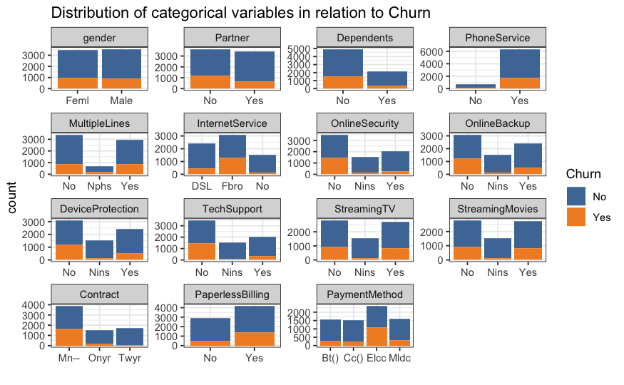

- Customers with dependents are less likely to churn
- Customers with Online security are less likely to churn
- Customers with Tech support are less likely to churn
- Customers with Month-to-Month contract are more likely to churn

## Numerical variables distribution

Check the distribution of the numerical variables concerning churn.

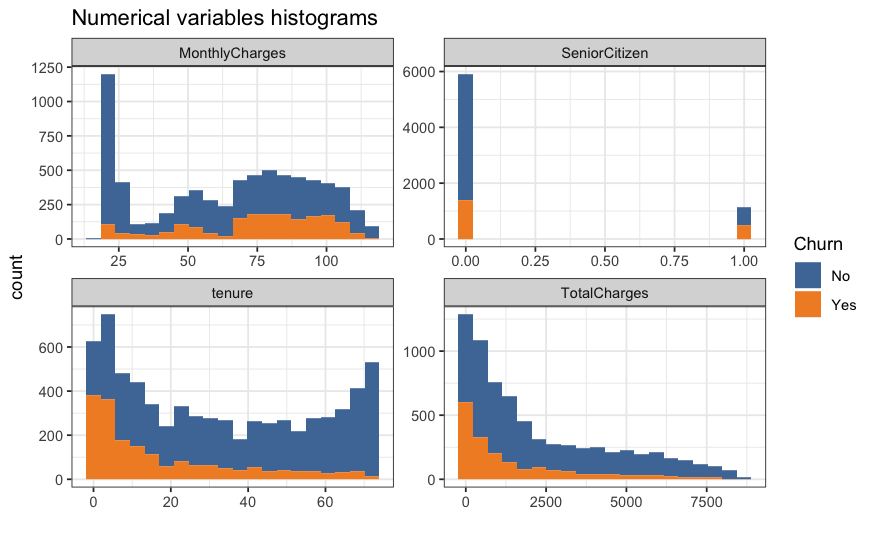

- All variables except Senior citizen seems to be continuous variables.
- It seems that higher tenure means lower probability of churn

## Correlation funnel

Correlation is a very important metric to understand the relationship between variables. The package correlationfunnel produces a chart, which helps us understand the relationship of all variables (categorical & numerical) with churn.

At first, it creates binary variables of each class of categorical variables and 4 bins of each numerical variable (based on quantiles). It plots all variables starting from the most correlated to the less correlated.

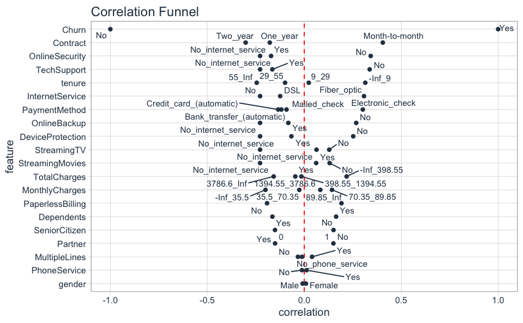

```r
# Create correlation Funnel
telco %>%
    binarize() %>%
    correlate(Churn__Yes) %>%
    plot_correlation_funnel()
```

Gender, Phone Service & MultipleLines seems to be unimportant for churn, as almost all classes are near zero correlated. During the model building phase, we can exclude these variables as part of our feature engineering.

On the other hand, Contract, Online Security, Tech support & tenure seems important.

# MODELLING

There are a lot of ways we could approach this churn problem. For example, the traditional approach is survival analysis techniques that mainly try to predict when a customer will probably churn.

But in our case, we’ll develop a machine learning model that will predict the churn probability for all customers.

## Split dataset

At first, we’re splitting the dataset into 2 parts, training & test dataset. We’ll use the training dataset to train our model & the testing dataset to check the performance of the model.

## Prepare the recipe of data for modeling

Here we’re using the recipes package to apply the same pre-processing steps to training & test data.

## Processing data according the recipe

## Setting the train controls for modeling

## Logistic Regression Model

```r
# Logistic_model <- train(Churn ~ .,
#                         data = train_data,
#                         method = 'glm',
#                         family = 'binomial',
#                         trControl = train_ctr,
#                         metric = 'ROC')
```

## Random Forest Model

We will use random tuning

```r
# rf_model <- train(Churn ~ .,
#                   data = train_data,
#                   method = 'rf',
#                   trControl = train_ctr,
#                   tuneLength = 5,
#                   metric = 'ROC')
```

## XGBoost Model

```r
# xgb_model <- train(Churn ~ ., data = train_data,
#                         method = 'xgbTree',
#                         trControl = train_ctr,
#                         tuneLength = 5,
#                         metric = 'ROC')
```

## Model Comparison

In this step we’ll compare the models accuracy.

```r
summary(model_list)
```

```
Call:
summary.resamples(object = model_list)

Models: Logistic, Random_forest, XgBoost
Number of resamples: 10

ROC
                   Min.   1st Qu.    Median      Mean   3rd Qu.      Max. NA's
Logistic      0.8146219 0.8423167 0.8532545 0.8490583 0.8617625 0.8674666    0
Random_forest 0.7859854 0.8180776 0.8280703 0.8291343 0.8473495 0.8608395    0
XgBoost       0.8218976 0.8389302 0.8500959 0.8478063 0.8581897 0.8665177    0

Sens
                   Min.   1st Qu.    Median      Mean   3rd Qu.      Max. NA's
Logistic      0.8756906 0.8964088 0.9046961 0.9055682 0.9152265 0.9281768    0
Random_forest 0.9198895 0.9288674 0.9448237 0.9433938 0.9571823 0.9669421    0
XgBoost       0.8950276 0.9143646 0.9157459 0.9138563 0.9213278 0.9228650    0

Spec
                   Min.   1st Qu.    Median      Mean   3rd Qu.      Max. NA's
Logistic      0.4732824 0.5057252 0.5229008 0.5247915 0.5381679 0.5954198    0
Random_forest 0.2977099 0.3282443 0.3511450 0.3567763 0.3762038 0.4198473    0
XgBoost       0.4198473 0.4942748 0.5152672 0.5080035 0.5267176 0.5572519    0
```

- Based on ROC (AUC value) the best model is Logistic regression.

The AUC value of the best model (mean of logistic regression) is 0.849. In general, models with an AUC value > 0.7 are considered as useful, depending of course on the context of the problem.

## Model evaluation

| true_class | logistic_churn | rf_churn | xgb_churn |
| --- | --- | --- | --- |
| No | 0.034491699 | 0.008 | 0.05259937 |
| Yes | 0.723830850 | 0.830 | 0.72653395 |
| No | 0.241754658 | 0.102 | 0.19181532 |
| No | 0.017231879 | 0.008 | 0.03235483 |
| No | 0.017398135 | 0.004 | 0.01546389 |
| No | 0.166011773 | 0.064 | 0.15635073 |
| No | 0.399824910 | 0.242 | 0.49826550 |
| No | 0.059624657 | 0.030 | 0.06256974 |
| Yes | 0.649404023 | 0.482 | 0.58964092 |
| No | 0.041991067 | 0.012 | 0.07085782 |

[output cut: 990 more lines]

## Roc curve

ROC curve or receiver operating characteristic curve is a plot that illustrates the diagnostic ability of a binary classifier system as its discrimination threshold is varied.

i.e. how well the model predicts at different thresholds

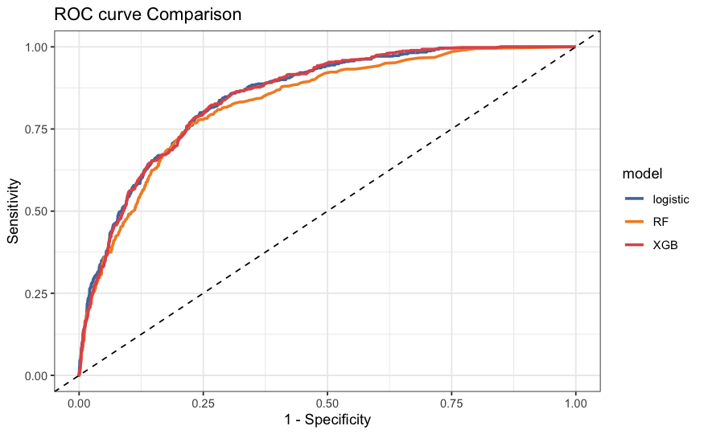

The largest the AUC value, the better is the model accuracy.

## Confusion matrix for logistic model

```r
# Use 0.5 as threshold for classifying the customers
pred_class <- ifelse(pred_logistic$Yes > 0.5, 'Yes', 'No') %>%
  as.factor()

confusionMatrix(pred_class, test_data$Churn, positive = 'Yes')
```

```
Confusion Matrix and Statistics

          Reference
Prediction   No  Yes
       No  1392  250
       Yes  160  310

               Accuracy : 0.8059
                 95% CI : (0.7883, 0.8225)
    No Information Rate : 0.7348
    P-Value [Acc > NIR] : 1.362e-14

                  Kappa : 0.4749

 Mcnemar's Test P-Value : 1.106e-05

            Sensitivity : 0.5536
            Specificity : 0.8969
         Pos Pred Value : 0.6596
         Neg Pred Value : 0.8477
             Prevalence : 0.2652
         Detection Rate : 0.1468
   Detection Prevalence : 0.2225
      Balanced Accuracy : 0.7252

       'Positive' Class : Yes
```

## Predict churn for new customers

```r
new_data <- read_csv(file = "./data/new_data.csv")

new_data_recipe  <- bake(recipe_obj, new_data)

new_dat_pred <-
  predict(Logistic_model, newdata = new_data_recipe, type = 'prob') %>%
  select(Yes) %>%
  rename(churn_prob = Yes) %>%
  bind_cols(new_data) %>%
  mutate(churn_group = ntile(churn_prob, n = 10)) %>%
  select(churn_prob, churn_group, tenure, Contract, TechSupport,  everything())

new_dat_pred %>% View()
```

# CONCLUSIONS

## Create a churn risk ranking

Although we developed a model that can predict pretty well if a customer will churn, the model output probabilities are not sufficient in the business context. We need some metric that will be understood & easily used by all stakeholders and remove the complexities of e.g. explaining a threshold to non-technical stakeholder.

So instead of an actual probability, a churn risk ranking would be more useful. So we break up the probabilities variable into 10 churn risk buckets. Now a customer has a churn risk from **1 (lowest probability) to 10 (highest probability)** .

## Tactics for churn prevention

Develop different sales offers (or marketing campaigns) for the different churn risk groups.

For example, customers that belong in churn risk groups 10 & 9 have a significantly higher churn risk than for example 1 & 2. So it will be crucial to offer them something more (discount, free upgrade etc.) in order to retain them.